# Reproducile Research - Peer Assessment 1

Stefano Svevo

Sunday, October 18th, 2015

## About this report

This report presents a study about personal movement using activity monitoring devices. Each of the steps followed will be detailed in subsequent paragraphs.

## Loading and preprocessing data

The data on which the study is based is contained in the *activity.zip* file, which we will unzip to a local file *activity.csv* and read into the variable **action**. Two manipulations must be performed on the data before we can start our analysis. These are:

1. dates must be read as strings, not factors
2. intervals must be recast from integers to strings in the **“HH:MM”** format

Subsequent analyses will require further manipulations to take care of missing values and derive new variables, but for the moment these two will suffice.

```r
# Unzip and read the data getting strings as strings:
unzip("activity.zip")
action <- read.csv("activity.csv",stringsAsFactors=FALSE)

# Load the stringr package to manipulate strings
library(stringr)

# Since the action$interval variable is of type integer, we will convert it to
# character, pad it with "0"s, and insert a ":" between hours and minutes
sInterval  <- as.character(action$interval)
              # converts interval from integer to character

psInterval <- sapply(X=sInterval,
                     FUN='str_pad',width=4,pad="0", USE.NAMES=FALSE)
              # pads the interval with "0"s to reach length 4

interval   <- sapply(X=psInterval,
                     FUN=function(ARG) {str_c(str_sub(ARG,1,2),":",str_sub(ARG,3,4))}, USE.NAMES=FALSE)
              # inserts ":" between the first and the last two characters of each interval

# Now replace the interval variable and check the result
action[,3] <- interval
head(action)
```

```
##   steps       date interval
## 1    NA 2012-10-01    00:00
## 2    NA 2012-10-01    00:05
## 3    NA 2012-10-01    00:10
## 4    NA 2012-10-01    00:15
## 5    NA 2012-10-01    00:20
## 6    NA 2012-10-01    00:25
```

## What is the mean total number of steps taken per day?

We plan to use the **dplyr** package to perform our analysis, so the first step will consist of loading the package and converting our dataframe variable to a table variable, using the *tbl_df* function. Our aim is to find the total number of steps for each day, and compute the mean and median total number of steps.

We will first group the rows of the table by date, and sum for each day the *steps* variable. In this phase we will ignore missing value, and will omit them from the computation. With the new table we can compute the mean and median of the total number of steps taken per day, and plot an histogram We will use the chaining rule to improve the readability of the code.

```r
library(dplyr, warn.conflicts = FALSE)
action_tbl <- tbl_df(action)   # convert to table
tot <- action_tbl %>%
       group_by(date) %>%
       summarize(totalSteps = sum(steps,na.rm=TRUE))   # group by date, sum the steps
```

Once we have the summarised data, we will produce a histogram (with breaks every 1000 steps) of the number of steps per day,

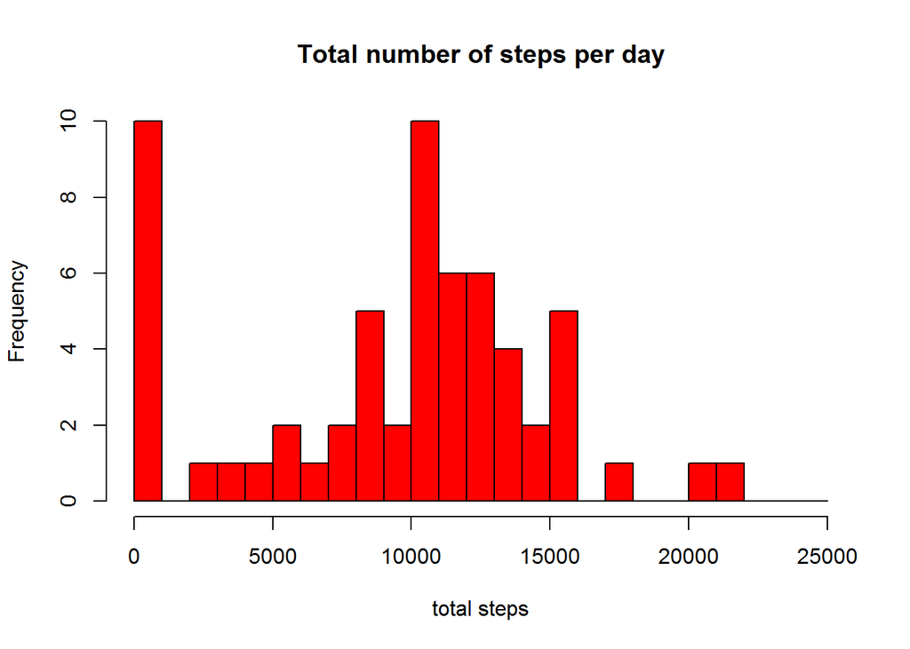

```r
hist(tot$totalSteps,
     breaks = seq(from=0, to=25000, by=1000),
     col="red",
     xlab="total steps",
     main="Total number of steps per day")
```

and compute mean and median:

```r
mean(tot$totalSteps)
```

```
## [1] 9354.23
```

```r
median(tot$totalSteps)
```

```
## [1] 10395
```

## What is the average daily activity pattern?

In order to analyze the daily activity pattern we will group the data by interval, and then compute the average across all days. We will use again the **dplyr** package and the chain rule to get a table with the daily activity pattern (dap):

```r
dap <- action_tbl %>%
       group_by(interval) %>%
       summarize( avgSteps = mean(steps, na.rm =TRUE)) # group by interval,
                                                       # take the mean
```

First of all let’s plot the data:

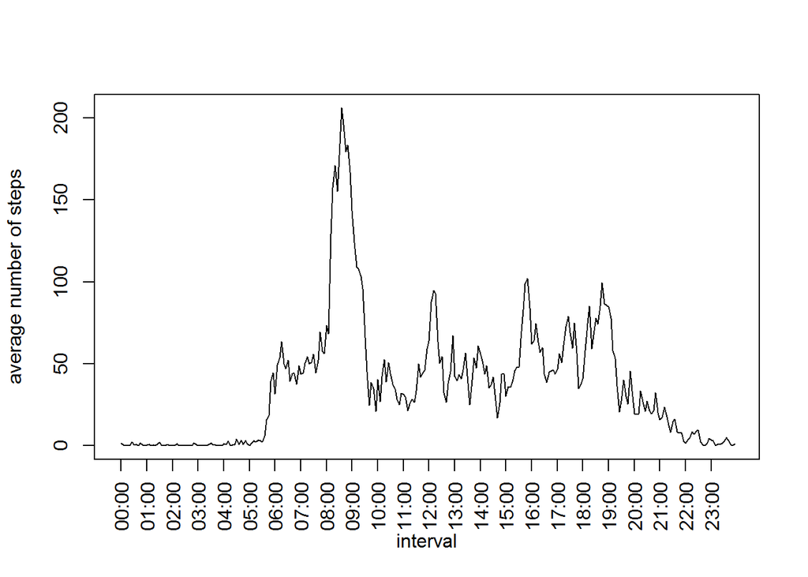

```r
range <- seq(1,288,by=12)  # place a label every hour (12 intervals)
plot(dap$avgSteps,
     xlim=c(0,288),
     type="l",
     ylab = "average number of steps",
     xlab = "interval",
     xaxt="n") # don't draw x-axe
axis(side = 1, at = range,labels=dap$interval[range],las=3)
```

Now we can look for the interval with the highest average number of steps:

```r
maxIndex=which(dap$avgSteps == max(dap$avgSteps))
dap$interval[maxIndex]
```

```
## [1] "08:35"
```

## Imputing missing values

The next step of our analysis concerns missing values. Of the 17568 rows of data, some don’t have values for the *steps* variable. The number of instances with missing data is:

```r
sum(is.na(action$steps))
```

```
## [1] 2304
```

We want to repeat the previous analysis without neglecting any instance, so We will now replace these missing values with the average value (across all the days) for the corresponding interval.

We will :

1. copy our original dataframe to a new one
2. get a vector containing the indices of the missing values
3. get a vector containing the interval of these indices
4. get (from **dap**) a vector containing the corresponding averages
5. set the corresponding *action$steps* variable

```r
newAction      <- action                              # copy original dataframe
voidIndices    <- which  ((is.na(newAction$steps)))   # find indices of NAs
voidIntervals  <- newAction$interval[voidIndices]        # corresponding intervals
substValues    <- sapply(voidIntervals,
                         FUN=function(ARG) {
                               dap$avgSteps[which(dap$interval == ARG)]  },USE.NAMES = FALSE)           # their averages
newAction$steps[voidIndices] <- substValues           # substitute
```

If we check for NAs now, we shouldn’t find any:

```r
sum(is.na(newAction$steps))
```

```
## [1] 0
```

we can now repeat the analysis of the mean total number of steps taken per day, with this new dataset and compare it with our previous one. First of all we will summarize the data, then plot the histogram, and finally compute mean and median of the total number of steps for each day.

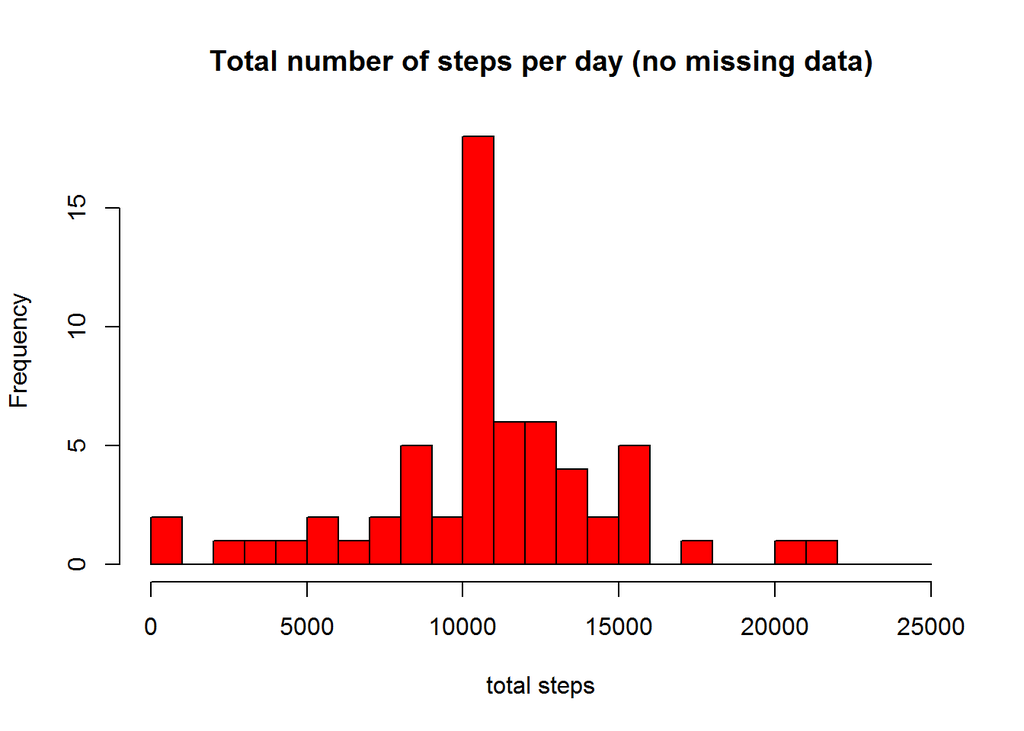

```r
newAction_tbl <- tbl_df(newAction)   # convert to table
newTot <- newAction_tbl %>%
       group_by(date) %>%
       summarize(totalSteps = sum(steps))   # group by date, sum the steps

hist(newTot$totalSteps,
     breaks = seq(from=0, to=25000, by=1000),
     col="red",
     xlab="total steps",
     main="Total number of steps per day (no missing data)")
```

```r
mean(newTot$totalSteps)
```

```
## [1] 10766.19
```

```r
median(newTot$totalSteps)
```

```
## [1] 10766.19
```

As we can see, substituting the missing values with the corresponding mean values for the intervals has increased both mean and median.

## Are there differences in activity patterns between weekdays and weekends?

First of all we will generate a new variable to separate weekdays from weekends, then we will use **dplyr** to obtain two tables.

```r
day <- sapply ( X=action$date, FUN=function(ARG) {
if (weekdays(as.Date.character(ARG)) == "Saturday" || weekdays(as.Date.character(ARG)) == "Sunday")
      { "weekend"}
else {"weekday"}
}, USE.NAMES =FALSE)

action[,4] <- day
names(action) <- c("steps","date","interval","day")
actionWD <- tbl_df(action[action$day == "weekday",])
actionWE <- tbl_df(action[action$day == "weekend",])

dapWD <- actionWD %>% group_by(interval) %>% summarize(avgSteps = mean(steps,na.rm =TRUE))
dapWE <- actionWE %>% group_by(interval) %>% summarize(avgSteps = mean(steps,na.rm =TRUE))
```

Plotting the values we see that the activity is considerably higher during the weekend afternoons, and that we start moving a bit later as compared to the weekdays.

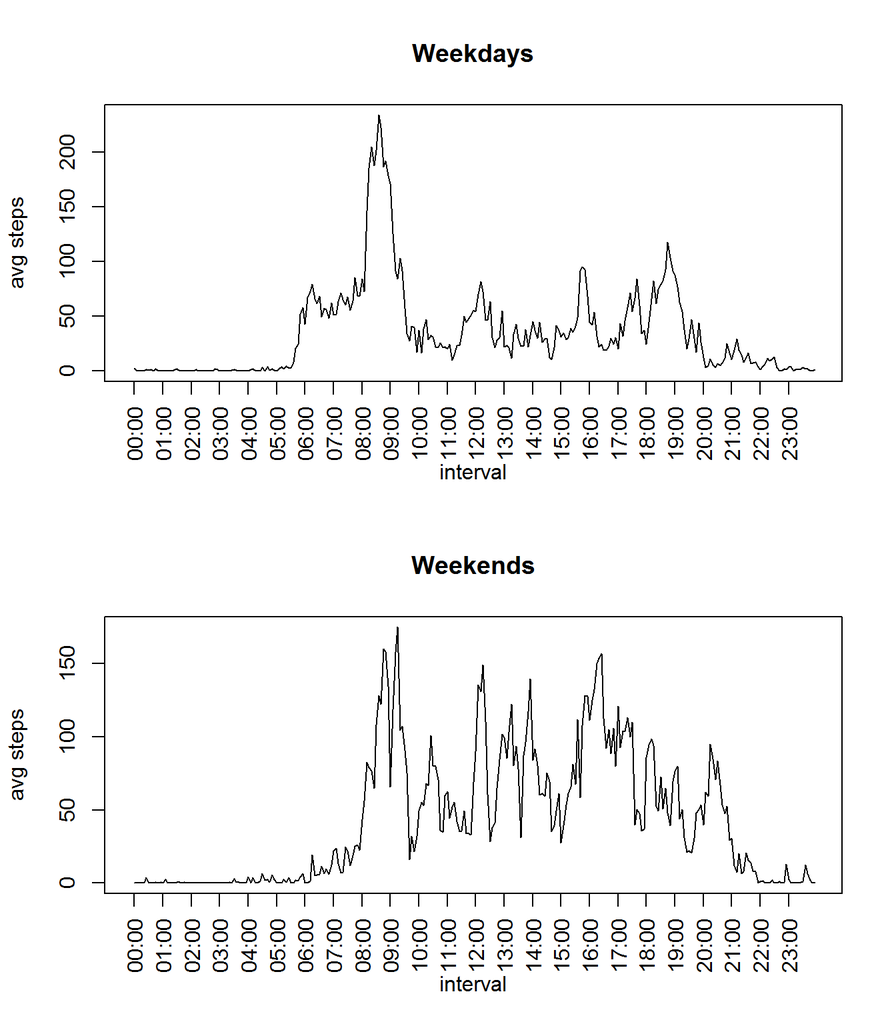

```r
par(mfrow=c(2,1))

range <- seq(1,288,by=12)  # place a label every hour (12 intervals)
plot(dapWD$avgSteps,
     main= "Weekdays",
     xlim=c(0,288),
     type="l",
     ylab = "avg steps",
     xlab = "interval",
     xaxt="n") # don't draw x-axe
axis(side = 1, at = range,labels=dapWD$interval[range],las=3)
plot(dapWE$avgSteps,
     main= "Weekends",
     xlim=c(0,288),
     type="l",
     ylab = "avg steps",
     xlab = "interval",
     xaxt="n") # don't draw x-axe
axis(side = 1, at = range,labels=dapWE$interval[range],las=3)
```